# Final Project

Team Dragon: Eric Jensen, Blake polozo, Oranich Boondiskulchok, Juan Rodriguez, and Xuanyi Liu

April 15, 2017

# Cleaning up data

```r
speed <- read.csv("Speed Dating Data.csv")
speed$condtn <- as.factor(speed$condtn)
speed$gender <- as.factor(speed$gender)
speed$match <- as.factor(speed$match)
speed$field_cd <- as.factor(speed$field_cd)
levels(speed$field_cd) <- c("Law","Math","SocScie/Psych", "MedSci", "Engineering", "English", "History", "Business", "Education", "Bio","SocialWork","Undergrad", "PoliSci", "Film","FineArts","Lang","Architecture","Other")
speed$race <- as.factor(speed$race)
speed$goal <- as.factor(speed$goal)
levels(speed$goal) <- c("FunNightOut", "MeetNewPpl", "GetADate","SRSRelationship", "ToSayIDidIt","Other")
speed$date <- as.factor(speed$date)
levels(speed$date) <- c("SVRL/Week","2/Week","1/Week","2/Month", "1/Month", "SVRL/Year", "AlmostNever")
speed$go_out <- as.factor(speed$go_out)
levels(speed$go_out) <- c("SVRL/Week","2/Week","1/Week","2/Month", "1/Month", "SVRL/Year", "AlmostNever")
speed$career_c <-as.factor(speed$career_c)
levels(speed$career_c) <- c("Lawyer","Academic/Research","Psychologist","DocMed", "Engineer", "Entertainment", "Banking/Consulting", "RealEstate","IntlAffairs","Undecided","SocialWork","SpeechPath","Politics", "ProSports", "Other", "Journalism", "Architecture")
speed$race_o <-as.factor(speed$race_o)
speed$dec_o <- as.factor(speed$dec_o)
speed$samerace <- as.factor(speed$samerace)

sd2 <- speed
sd2 <- sd2[ , -1] #IID
sd2 <- sd2[, -1] #ID
sd2 <- sd2[, -2] #IDG
sd2 <- sd2[, -3] #Wave
sd2 <- sd2[, -3] #Round
sd2 <- sd2[, -3] #Position
sd2 <- sd2[, -3] #Postion1
sd2 <- sd2[, -4] #Partner
sd2 <- sd2[, -4] #PID
sd2 <- sd2[, -26]#Field
sd2 <- sd2[, -(27:29)]#Academics
sd2 <- sd2[,-(30:32)]#Socioeconomic
sd2 <- sd2[,-33]#Career
sd2 <- sd2[,-(59:64)]#What others look for
sd2 <- sd2[,-(70:74)]#Others perception
sd2 <- sd2[,-(81:92)]#Data gathered after intitial
sd2 <- sd2[,(1:79)]
sd2 <- sd2[,-(70:79)] #Removes Post First Date
sd2 <- sd2[,-52]#exclude expnum
sd3 <- cbind(sd2, speed[, 6])
sd4 <- sd2

sdrandom <- sd2[sample(nrow(sd2), nrow(sd2)),] #Get a random sample since the data is organized by participant
sdrandom1 <-sd3[sample(nrow(sd3), nrow(sd3)),]

sdclean <- na.omit(sdrandom) #Remove rows with NA values to create a "clean" set
sdclean1 <- na.omit(sdrandom1)

names(sdclean1)[69] <- "wave"
sdclean1[, 69] <- as.factor(sdclean1[, 69])

#Adding month given wave period
sdclean1$month <- ifelse(sdclean1$wave == 1, "October", ifelse(sdclean1$wave == 2, "October", ifelse(sdclean1$wave == 3, "November", ifelse(sdclean1$wave == 4, "November", ifelse(sdclean1$wave == 5, "November", ifelse(sdclean1$wave == 6, "March", ifelse(sdclean1$wave == 7, "March", ifelse(sdclean1$wave == 8, "April", ifelse(sdclean1$wave == 9, "April", ifelse(sdclean1$wave == 10, "September", ifelse(sdclean1$wave == 11, "September", ifelse(sdclean1$wave == 12, "October", ifelse(sdclean1$wave == 13, "October", ifelse(sdclean1$wave == 14, "October", ifelse(sdclean1$wave == 15, "February", ifelse(sdclean1$wave == 16, "February", ifelse(sdclean1$wave == 17, "February", ifelse(sdclean1$wave == 18, "April", ifelse(sdclean1$wave == 19, "April", ifelse(sdclean1$wave == 20, "April",ifelse(sdclean1$wave == 21, "April", NA
                        )))))))))))))))))))))

#Creating model matrix
data <- as.data.frame(model.matrix(~. -1, data = sdclean))

#removing match1
data$match <- as.factor(data$match1)
data$match1 <- NULL

# Rescale the data
normalize <- function(x) {
  return((x-min(x)) / (max(x) - min(x)))
}

data <-as.data.frame(lapply(data, function(x){
  if((class(x[1]) != "numeric") & (class(x[1]) != "integer")) {
    return (x)
  }
  return(normalize(x))
}))

#setting y as a factor
data$y <- as.factor(data$match)
data$match <- NULL

#splitting data into training and test
train <- data[1:5199, ]
test <- data[5200:6499, ]
```

# Matching Based on Month

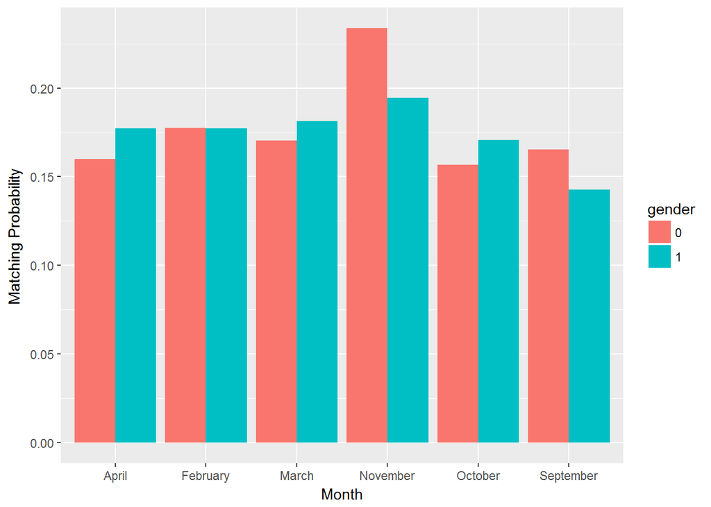

```r
explore <- sdclean1 #Adding separate variable

explore$match <- as.numeric(ifelse(explore$match == 1,1,0)) #adjusting match

month.match.ratio <- explore %>% group_by(gender, month) %>% summarise(match.prop = mean(match)) #Segmenting out by month and gender

ggplot(month.match.ratio, aes(x = month, y = match.prop, fill = gender)) + geom_col(position = "dodge")+ ylab("Matching Probability") + xlab("Month")
```

Individuals, particularly women, are more likely to match in November than in any other month. This is likely in anticipation of the holiday season. Knowing this, okMatch should look into providing dating rounds in December to take advantage of this season of higher matching.

# Matching Based on Interest Correlation

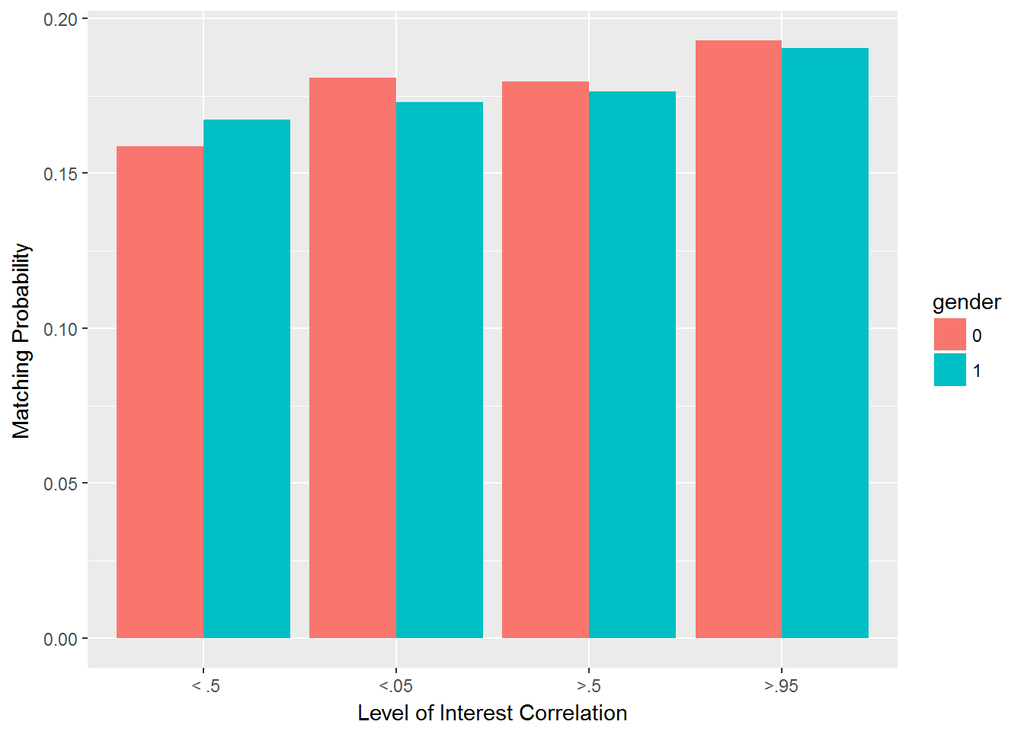

```r
explore$int_corr <- as.factor(ifelse(explore$int_corr < -0.3355, "<.05",
                                        ifelse(explore$int_corr< .1965, " < .5",
                                        ifelse(explore$int_corr <.655 , ">.5", ">.95")))) #Relabling interest correlation by quantile

int.match.ratio <- explore %>% group_by(gender, int_corr) %>% summarise(match.prop = mean(match)) #Subsetting gender and interest correlation

ggplot(int.match.ratio, aes(x = int_corr, y = match.prop, fill = gender)) + geom_col(position = "dodge")+ ylab("Matching Probability") + xlab("Level of Interest Correlation")
```

You would think that matching would be proportional to the level of interest correlation but that isn’t true! With women in particular, if you have an interest correlation of below 5%, you are still more likely to match than any other group other than an interest correlation of 95% or higher.

# Matching Based on Expected Happiness with Dates

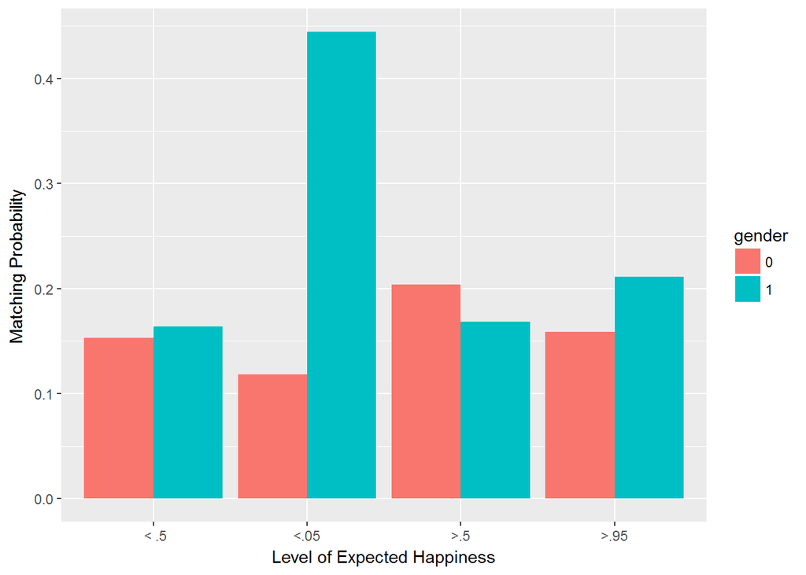

```r
explore$exphappy <- as.factor(ifelse(explore$exphappy < 2, "<.05",
                                        ifelse(explore$exphappy< 5.5, " < .5",
                                        ifelse(explore$exphappy <8 , ">.5", ">.95")))) #Segmenting expected happiness

exhappy.match.ratio <- explore %>% group_by(gender, exphappy) %>% summarise(match.prop = mean(match))#Subsetting expected happiness by gender

ggplot(exhappy.match.ratio, aes(x = exphappy, y = match.prop, fill = gender)) + geom_col(position = "dodge")+ ylab("Matching Probability") + xlab("Level of Expected Happiness")
```

Men who go into a date expected to no be happy with their partners are much more likely to match. This could be an issue of low sample size, or they don’t expect anything with their partners so they’ll match with anyone.

# Matching Based on Age

Age profile of people who participated in the events

```r
summary(explore$age)
```

```
##    Min. 1st Qu.  Median    Mean 3rd Qu.    Max.
##   18.00   24.00   26.00   26.33   28.00   55.00
```

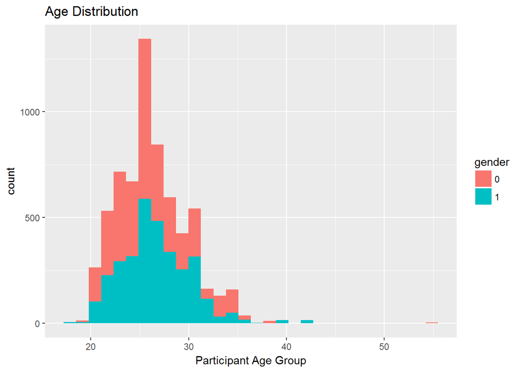

```r
ggplot(explore, aes(x=age , fill=gender))+ geom_histogram() + ggtitle("Age Distribution") + xlab("Participant Age Group")
```

Divide age of participants into <25, 25-30, 31-35, 36-40, 41-50, >50

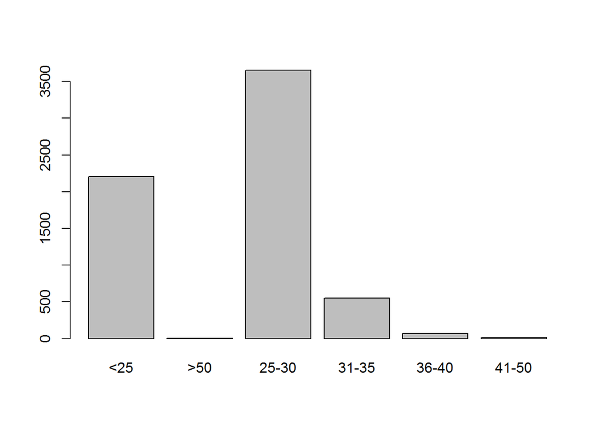

```r
explore.age <- explore
explore.age$participant.age.group <- as.factor(ifelse(explore$age<25, "<25",
                                        ifelse(explore$age<31, "25-30",
                                        ifelse(explore$age<36, "31-35",
                                        ifelse(explore$age<41, "36-40",
                                        ifelse(explore$age<51,"41-50",">50"))))))

#See the distribution of each age group
plot(explore.age$participant.age.group)
```

```r
table(explore.age$participant.age.group)
```

```
##
##   <25   >50 25-30 31-35 36-40 41-50
##  2204     4  3654   553    68    16
```

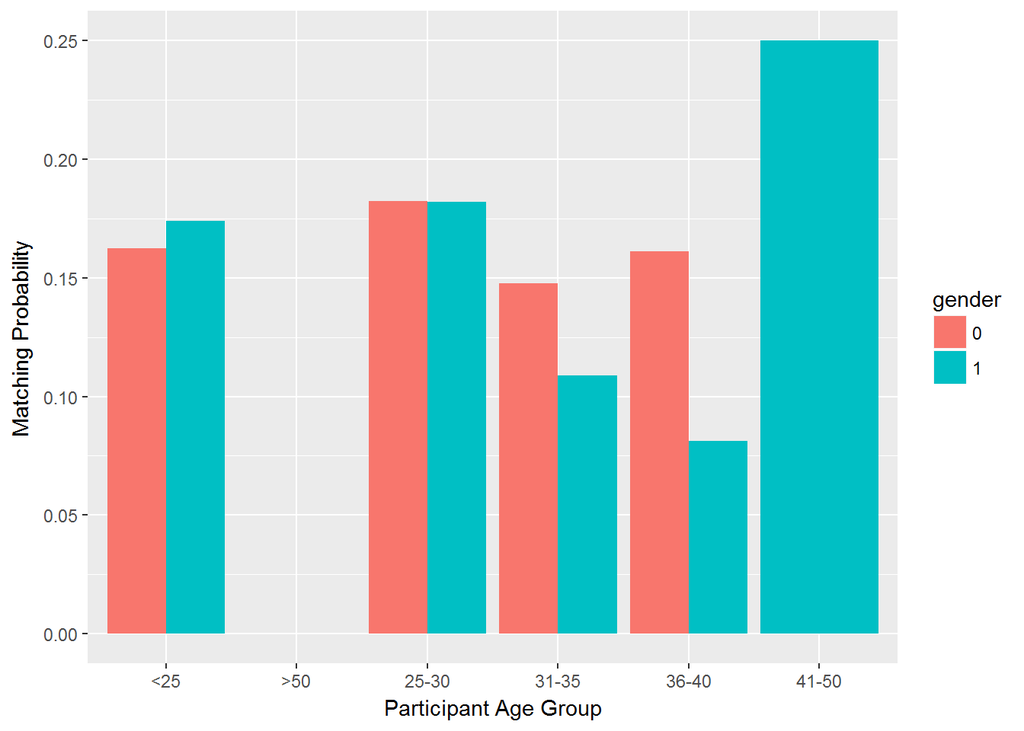

```r
#To calculate percentage of matching easier, convert "Yes" and "No" into numerical value 0,1
explore.age$match <- as.numeric(ifelse(explore$match == 1,1,0))

age.match.ratio <- explore.age %>% group_by(gender, participant.age.group) %>% summarise(match.prop = mean(match))

ggplot(age.match.ratio, aes(x = participant.age.group, y = match.prop, fill = gender)) + geom_col(position = "dodge")+ ylab("Matching Probability") + xlab("Participant Age Group")
```

Since there are only male in participant age group 41-50, there is only probability of matching for male sample. Interestingly, this group of male aged 41-50 has the highest probability to match. 1 in 4 of this sample group matched. In the most popular age group, the probability of male and female to match is really close, and male has slightly higher probability to match in group of age less than 25.

# Age correlation of participants and partners

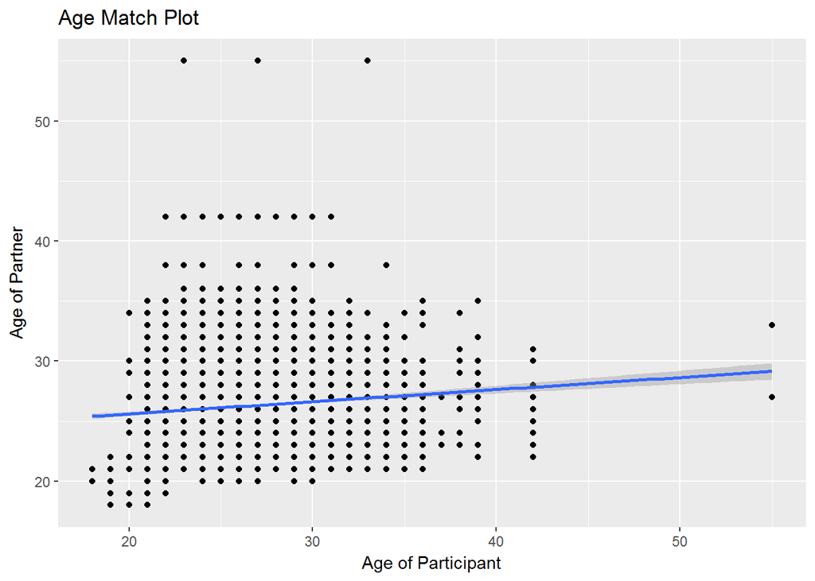

```r
#Plot age of participant and age of partner

age.match <- explore.age[c("age","age_o")]
ggplot(age.match, aes(x = age, y = age_o)) + geom_point()+ geom_smooth(method=lm) +ylab("Age of Partner")+ xlab("Age of Participant")+ggtitle("Age Match Plot")
```

```r
#Age of participant and age of partner correlation

cor(age.match$age, age.match$age_o)
```

```
## [1] 0.103857
```

# Matching Based on Race

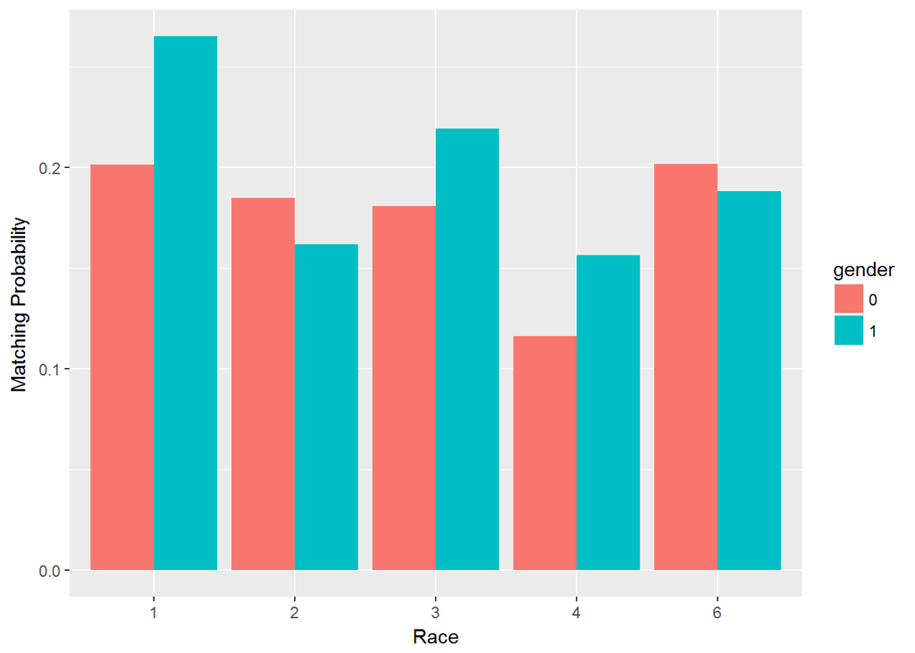

```r
explore$match <- as.numeric(ifelse(explore$match == 1,1,0))
race.match.ratio <- explore  %>% group_by(gender, race_o) %>% summarise(match.prop = mean(match))

ggplot(race.match.ratio, aes(x = race_o, y = match.prop, fill = gender)) + geom_col(position = "dodge")+ ylab("Matching Probability") + xlab("Race")
```

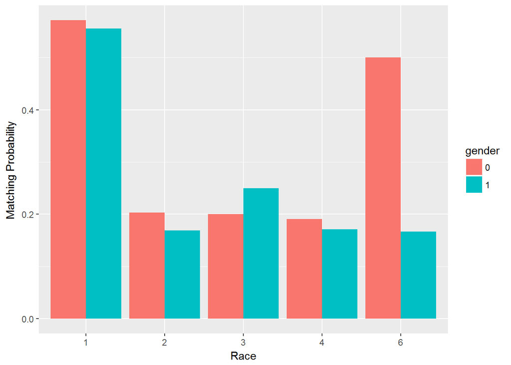

```r
#Subsetting based on race
Black <- subset(explore, explore$race == 1)
White <- subset(explore, explore$race == 2)
Latino <- subset(explore, explore$race == 3)
Asian <- subset(explore, explore$race == 4)
Native <- subset(explore, explore$race == 5)
Other <- subset(explore, explore$race == 6)

black.match.ratio <- Black %>% group_by(gender, race_o) %>% summarise(match.prop = mean(match))

ggplot(black.match.ratio, aes(x = race_o, y = match.prop, fill = gender)) + geom_col(position = "dodge")+ ylab("Matching Probability") + xlab("Race")
```

Black people are the most likely to match and are significantly more likely to match with each other.

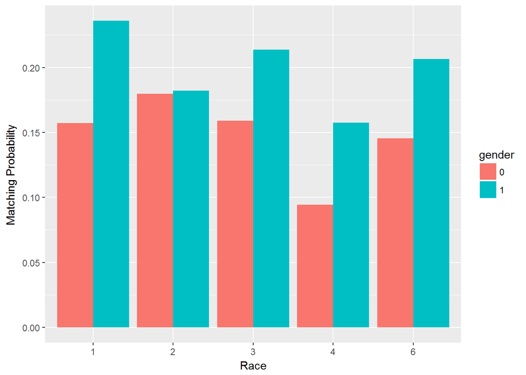

```r
white.match.ratio <- White %>% group_by(gender, race_o) %>% summarise(match.prop = mean(match))

ggplot(white.match.ratio, aes(x = race_o, y = match.prop, fill = gender)) + geom_col(position = "dodge")+ ylab("Matching Probability") + xlab("Race")
```

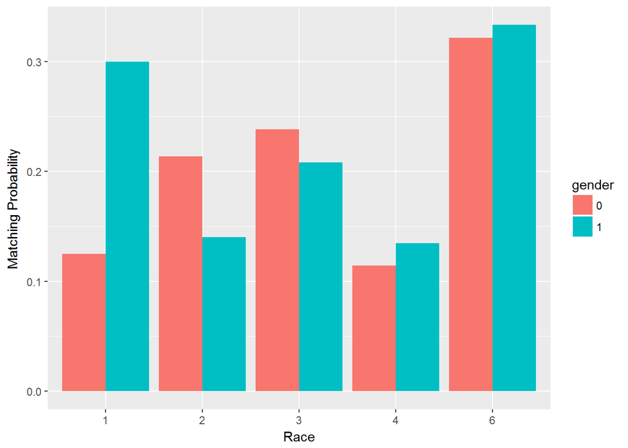

```r
latino.match.ratio <- Latino %>% group_by(gender, race_o) %>% summarise(match.prop = mean(match))

ggplot(latino.match.ratio, aes(x = race_o, y = match.prop, fill = gender)) + geom_col(position = "dodge")+ ylab("Matching Probability") + xlab("Race")
```

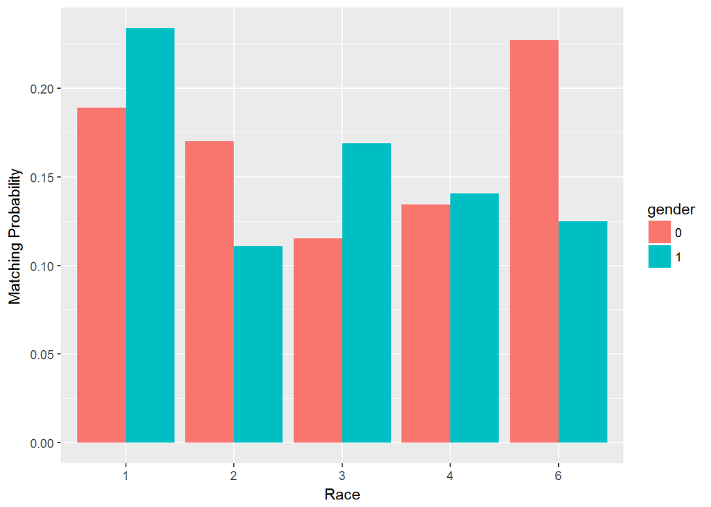

```r
asian.match.ratio <- Asian %>% group_by(gender, race_o) %>% summarise(match.prop = mean(match))

ggplot(asian.match.ratio, aes(x = race_o, y = match.prop, fill = gender)) + geom_col(position = "dodge")+ ylab("Matching Probability") + xlab("Race")
```

# Matching Based on Career

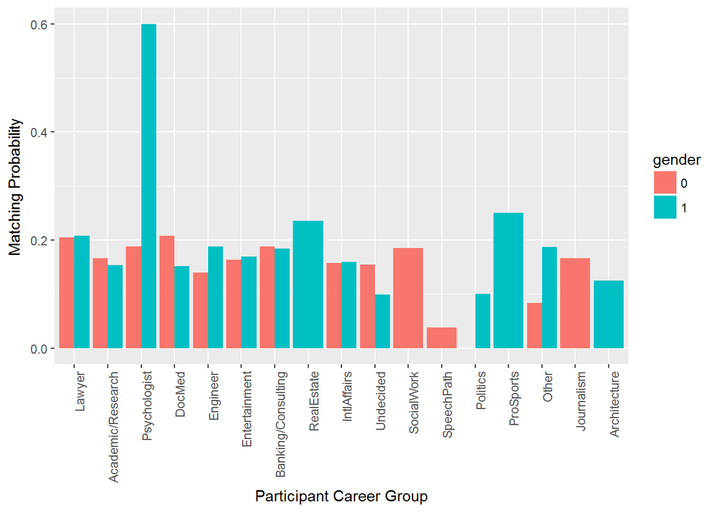

```r
#Subsetting based on career
career.match.ratio <- explore %>% group_by(gender, career_c ) %>% summarise(match.prop = mean(match))

ggplot(career.match.ratio, aes(x = career_c, y = match.prop, fill = gender)) + geom_col(position = "dodge")+ ylab("Matching Probability") + xlab("Participant Career Group") + theme(axis.text.x = element_text(angle = 90, hjust=1))
```

# Logistic Models

```r
library(caret)
## 10-fold CV
fitControl <- trainControl(method = "cv",
                           number = 10,
                           selectionFunction = "oneSE",
                           verboseIter = T)


# ===================================================
# Logistic Models
# ===================================================

run_all_log_models = F #Change to create own model

if (run_all_log_models) {
  log <- glm(y~., train, family = "binomial") #used binomial bc works well for binary outcomes and continuous predictors
  #Stepped forward model
  log_f <- colnames(train) %>%
  {paste(.[! . %in% "y"], collapse = " + ")} %>%
    paste("y~ ", .) %>% as.formula()
  log_stepped <-glm(y~1, train, family = "binomial")
  log_stepped <- step(log_stepped, scope = (log_f), direction = "forward")

   #Boosted logistic Model
  log_boosted <- caret::train(y ~ . , data = train,
                              method = "LogitBoost",
                              trcontrol = fitControl,
                              metric = "Accuracy")

  save(log, file = "log.txt")
  save(log_stepped, file = "log_stepped.txt")
  save(log_boosted, file = "log_boosted.txt")
} else {
  load(file = "log.txt")
  load(file = "log_stepped.txt")
  load(file = "log_boosted.txt")
}
```

# SVM

```r
#========================
# SVM Models
#========================

library(kernlab)

run_all_svm_models = F #change to create own model

#Running SVM models
if (run_all_svm_models) {
  svm_model1 <- ksvm(y~., data = train, kernel = "vanilladot")
  svm_model2 <- ksvm(y ~ ., data = train, kernel = "rbfdot")

  # #Bagged svm did not work, "said something is wrong"
  # bagctrl <- bagControl(fit = svmBag$fit, predict = svmBag$pred, aggregate = svmBag$aggregate)
  # set.seed(200)
  # svmbag <- train(y ~ ., data = train, "bag",trControl = ctrl, bagControl = bagctrl)

  save(svm_model1, file = "svm_model1.txt")
  save(svm_model2, file = "svm_model2.txt")
} else {
  load(file = "svm_model1.txt")
  load(file = "svm_model2.txt")
}
```

# KNN

```r
#===================
# KNN Models
#===================

#Setting up the data
knn_train_labels <- train[,120]
knn_test_labels <- test[,120]

#Running KNN models
run_all_knn_models = F

if (run_all_knn_models) {
  knn_pred <- knn(train = train, test = test, cl = knn_train_labels, k = 3)
  set.seed(400)
  ctrl <- trainControl(method="repeatedcv",repeats = 3)
  knnFit <- train(y ~ ., data = train, method = "knn", trControl = ctrl, preProcess = c("center","scale"), tuneLength = 20)
  #K of 15 ended up being used

  #Save the models
  save(knn_pred, file = "knn_pred.txt")
  save(knnFit, file = "knnFit.txt")
} else {
  load(file = "knn_pred.txt")
  load(file = "knnFit.txt")
}

knnFit
```

```
## k-Nearest Neighbors
##
## 5199 samples
##  119 predictor
##    2 classes: '0', '1'
##
## Pre-processing: centered (119), scaled (119)
## Resampling: Cross-Validated (10 fold, repeated 3 times)
## Summary of sample sizes: 4679, 4679, 4679, 4680, 4680, 4679, ...
## Resampling results across tuning parameters:
##
##   k   Accuracy   Kappa
##    5  0.8215086  0.19356282
##    7  0.8203527  0.13259814
##    9  0.8256726  0.11726551
##   11  0.8265057  0.09929781
##   13  0.8283661  0.08901515
##   15  0.8287509  0.07017133
##   17  0.8279811  0.05792265
##   19  0.8273391  0.04573767
##   21  0.8281731  0.04488258
##   23  0.8282376  0.03971237
##   25  0.8281094  0.03399468
##   27  0.8286215  0.03049753
##   29  0.8282367  0.02468089
##   31  0.8281726  0.02223483
##   33  0.8283648  0.02168343
##   35  0.8283649  0.02076572
##   37  0.8282367  0.01817918
##   39  0.8280443  0.01589454
##   41  0.8278520  0.01409130
##   43  0.8275953  0.01168930
##
## Accuracy was used to select the optimal model using  the largest value.
## The final value used for the model was k = 15.
```

```r
#Predict on tuned model
knnPredict <- predict(knnFit,newdata = test)
```

# Neural Networks

```r
#==============================
# Neural Networks
#==============================
library(neuralnet)

nndata <- as.data.frame(model.matrix(~. +0, data = data))
nndata$y0 <- NULL
nndata$y <- nndata$y1
nndata$y1 <- NULL

trainNN <- nndata[1:5199, ]
testNN <- nndata[5200:6499, ]

n <- names(nndata)
#Create Formula for all names in the dataframe
f <- as.formula(paste("y ~", paste(n[!n %in% "y"], collapse = " + ")))

run_all_nn_models = F

if (run_all_nn_models) {
  nn1 <- neuralnet(f,trainNN, hidden = 1)
  nn3 <- neuralnet(f,trainNN, hidden = 3)

  #Save the models
  save(nn1, file = "neural_model_1.txt")
  save(nn3, file = "neural_model_3.txt")
} else {
  load(file = "neural_model_1.txt")
  load(file = "neural_model_3.txt")
}
```

# Tree Models

```r
#==============================
# Tree based models
#==============================
library(party)
library(randomForest)
library(ada)
library(dplyr)
library(class)

run_all_tree_models = F

if(run_all_tree_models){
  tree_model <- ctree(y ~ ., data = train,
                      control = ctree_control(mincriterion = .99))
  tree_random_forest <- randomForest(y~., data = train)
  # Ada Tree
  tree_ada <- ada(y~., data = train)
  #Modify forests
  ctrl <- trainControl(method = "repeatedcv",
                     number = 10, repeats = 10)
# auto-tune a random forest
  grid_rf <- expand.grid(.mtry = c(2, 4, 8, 16))
  set.seed(300)
  #Modified Random Forest
  m_rf <- train(y ~ ., data = train, method = "rf",
              metric = "Kappa", trControl = ctrl,
              tuneGrid = grid_rf)

  save(m_rf, file = "modified_random_forest.txt")
  save(tree_model, file = "tree_model.txt")
  save(tree_random_forest, file = "tree_random_forest.txt")
  save(tree_ada, file = "tree_ada.txt")
} else {
  load(file = "modified_random_forest.txt")
  load(file = "tree_model.txt")
  load(file = "tree_random_forest.txt")
  load(file = "tree_ada.txt")
}
```

# Predictions

```r
#Logistic
log_prediction <- predict(log, test, type = "response") %>%
{ifelse(. > 0.5, "1", "0")} %>% as.factor()
log_stepped_prediciton <- predict(log_stepped, test, type = "response")%>%
{ifelse(. > 0.5, "1", "0")} %>% as.factor()
log_boosted_prediction <- predict(log_boosted, test, type = "raw")
#Neural Networks
neuralnet_prediction1 <- neuralnet::compute(nn1, testNN[,1:119])$net.result %>% {ifelse(. > 0.5, "1", "0")} %>% as.factor()
neuralnet_prediction3 <- neuralnet::compute(nn3, testNN[,1:119])$net.result %>% {ifelse(. > 0.5, "1", "0")} %>% as.factor()

#Tree Based
tree_prediction <- predict(tree_model, test)
tree_random_forest_prediction <- predict(tree_random_forest, test)
tree_ada_prediction <- predict(tree_ada, test)
tree_m_rf_prediction <- predict(m_rf, test)
```

# Checking accuracy

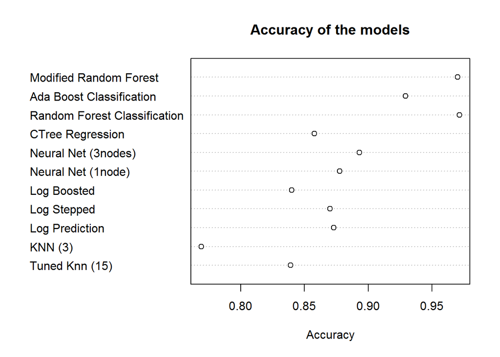

```r
accuracy <- function(predicted, trueval, model, hideoutput = F) {
  stopifnot(length(predicted) == length(trueval))
  result <- sum(predicted == trueval) / length(predicted)
  if (!hideoutput) {cat("Model:", model, "had", result, "accuracy\n")}
  return(result)
}
a1 <-accuracy(knnPredict, test$y, "KNN (15)", T)
a2 <-accuracy(knn_pred, test$y, "KNN (3)", T)
a3 <-accuracy(log_prediction, test$y, "Log Prediction", T)
a4 <-accuracy(log_stepped_prediciton, test$y, "Log Stepped", T)
a5 <- accuracy(log_boosted_prediction, test$y, "Log Boosted", T)
a6 <- accuracy(neuralnet_prediction1, testNN$y, "Neural Net (1 node)", TRUE)
a7 <- accuracy(neuralnet_prediction3, testNN$y, "Neural Net (3 nodes)", TRUE)
a8 = accuracy(tree_prediction, test$y, "CTree Regression", TRUE)
a9 = accuracy(tree_random_forest_prediction, test$y, "Random Forest Classification", TRUE)
a10 = accuracy(tree_ada_prediction, test$y, "Ada Boost Classification", TRUE)
a11 = accuracy(tree_m_rf_prediction, test$y, "Modified Random Forest", TRUE)

acc_predictions = c(a1, a2, a3, a4, a5, a6, a7, a8,a9,a10, a11)
names = c("Tuned Knn (15)", "KNN (3)", "Log Prediction","Log Stepped", "Log Boosted", "Neural Net (1node)", "Neural Net (3nodes)", "CTree Regression","Random Forest Classification","Ada Boost Classification", "Modified Random Forest")

dotchart(acc_predictions, labels = names, main = "Accuracy of the models", xlab = "Accuracy")
```

Best models were modified random forest and random forest classification. #Stacked Model This combines all the other previous models

```r
# ==========================================================
# Get the various predictions for the train data
# ==========================================================

knn_pred_train <- knn(train = train, test = train, cl = knn_train_labels, k = 3)
knnPredict_train <- predict(knnFit,newdata = train)
log_prediction_train <- predict(log, train, type = "response") %>%
{ifelse(. > 0.5, "1", "0")} %>% as.factor()
```

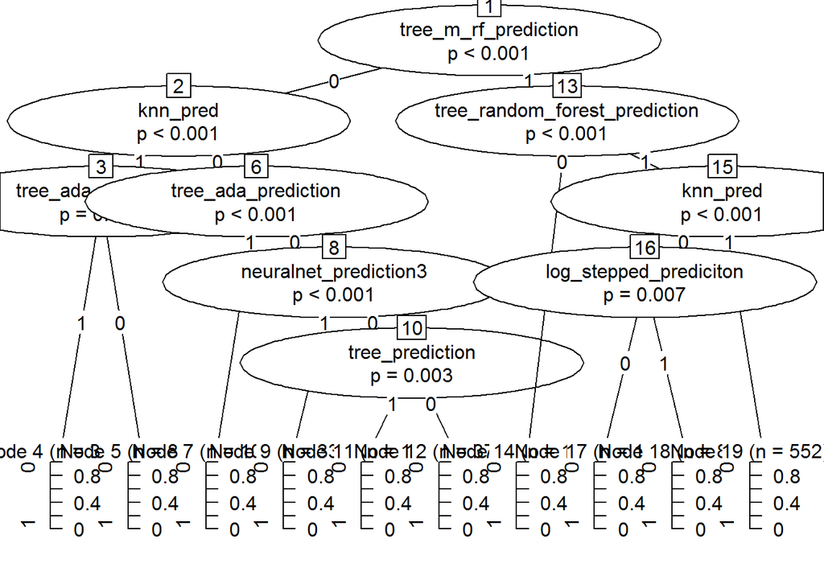

```r
log_stepped_prediction_train <- predict(log_stepped, train, type = "response")%>%
{ifelse(. > 0.5, "1", "0")} %>% as.factor()
log_boosted_prediction_train <- predict(log_boosted, train, type = "raw")
neuralnet_prediction1_train <- neuralnet::compute(nn1, trainNN[,1:119])$net.result %>% {ifelse(. > 0.5, "1", "0")} %>% as.factor()
neuralnet_prediction3_train <- neuralnet::compute(nn3, trainNN[,1:119])$net.result %>% {ifelse(. > 0.5, "1", "0")} %>% as.factor()
tree_prediction_train <- predict(tree_model, train)
tree_random_forest_prediction_train <- predict(tree_random_forest, train)
tree_ada_prediction_train <- predict(tree_ada, train)
tree_m_rf_prediction_train <- predict(m_rf, train)

#Combined Model
model_combined_results <- data.frame(log_prediction_train, log_boosted_prediction_train, log_stepped_prediction_train, knn_pred_train, knnPredict_train, neuralnet_prediction1_train, neuralnet_prediction3_train, tree_prediction_train, tree_random_forest_prediction_train, tree_ada_prediction_train, tree_m_rf_prediction_train) %>% as.tbl()

# Convert all of the feature data to factors
ConvertToYesNo <- function(myprediction) {
  result <- myprediction %>% as.factor()
  levels(result) <- c("0", "1")
  result
}

# Convert each set of predictions to factors
knnPredict %<>% ConvertToYesNo()
knn_pred %<>% ConvertToYesNo()
log_prediction %<>% ConvertToYesNo()
log_boosted_prediction %<>% ConvertToYesNo()
log_stepped_prediciton %<>% ConvertToYesNo()
neuralnet_prediction1 %<>% ConvertToYesNo()
neuralnet_prediction3 %<>% ConvertToYesNo()
tree_prediction %<>% ConvertToYesNo()
tree_random_forest_prediction %<>% ConvertToYesNo()
tree_ada_prediction %<>% ConvertToYesNo()
tree_m_rf_prediction %<>% ConvertToYesNo()

stacked_data <- data.frame(log_prediction, log_boosted_prediction, log_stepped_prediciton, knn_pred, knnPredict, neuralnet_prediction1, neuralnet_prediction3, tree_prediction, tree_random_forest_prediction, tree_ada_prediction, tree_m_rf_prediction) %>% as.tbl()

# Swap out the names
names(model_combined_results) <- names(stacked_data)

#Stacked Ctree model
stacked_model <- ctree(train$y ~ . + 1, data = model_combined_results, controls = ctree_control(mincriterion = .95)) %T>% plot
```

```r
stacked_model_prediction = predict(stacked_model, stacked_data, type = "response")
# Convert the levels into something that the factors can compare
stacked_model_prediction <- ConvertToYesNo(stacked_model_prediction)
accuracy(stacked_model_prediction, test$y, "Stacked Model Accuracy")
```

```
## Model: Stacked Model Accuracy had 0.8915385 accuracy
```

```
## [1] 0.8915385
```

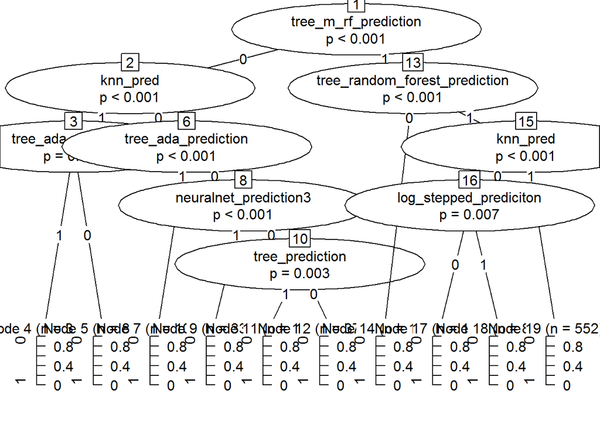

```r
#Good model can talk about how the low knn is helping the model
plot(stacked_model)
```

From the stacked model, we can see that tree_m_rf_prediction from the tree random forest model mostly made a call whether the couple is going to match or not. However, KNN model will becomes a decision call when tree_m_rf_prediction predict no and KNN predict yes. In this case, the stacked model predict that the couple is going to match.

# Cost model in a start-up stage

We further improve the decision tree model by assigning the cost matrix. As this okMatch is a startup business, we would want to set the primary goal to match as many people as possible. In other words, we can accept some positive error (the bad dates), that is, the couple is not actually match, but our platform predicts that they are going to match, if that means we can generate the most match possible (true positive).

```r
#decision tree
#Determine lots of matching to maximum no. of dates (False positive) VS determine lots of corrected matching on the expense of some possible match missed (False negative)
#startup vs match.com
#Adding Error Costs

#This increases total number of matches, flip matrix to be more selective on matches
error_cost_max_match <- matrix(c(0, 1, 20, 0), nrow = 2)

#Cost Model maximum the number of matching as an expense with false positive
cost_stacked_model_max_match <- C5.0(train$y ~ . + 1, data = model_combined_results, costs = error_cost_max_match)
#Prediction
cost_model_prediction_max_match = predict(cost_stacked_model_max_match, stacked_data, type = "class")

accuracy(cost_model_prediction_max_match, test$y, "Stacked Model Accuracy")
```

```
## Model: Stacked Model Accuracy had 0.8515385 accuracy
```

```
## [1] 0.8515385
```

```r
#comparing to previous model
confusionMatrix(cost_model_prediction_max_match, test$y)
```

```
## Confusion Matrix and Statistics
##
##           Reference
## Prediction   0   1
##          0 900  11
##          1 182 207
##
##                Accuracy : 0.8515
##                  95% CI : (0.831, 0.8704)
##     No Information Rate : 0.8323
##     P-Value [Acc > NIR] : 0.03295
##
##                   Kappa : 0.595
##  Mcnemar's Test P-Value : < 2e-16
##
##             Sensitivity : 0.8318
##             Specificity : 0.9495
##          Pos Pred Value : 0.9879
##          Neg Pred Value : 0.5321
##              Prevalence : 0.8323
##          Detection Rate : 0.6923
##    Detection Prevalence : 0.7008
##       Balanced Accuracy : 0.8907
##
##        'Positive' Class : 0
##
```

```r
confusionMatrix(stacked_model_prediction, test$y)
```

```
## Confusion Matrix and Statistics
##
##           Reference
## Prediction   0   1
##          0 973  32
##          1 109 186
##
##                Accuracy : 0.8915
##                  95% CI : (0.8734, 0.9079)
##     No Information Rate : 0.8323
##     P-Value [Acc > NIR] : 1.057e-09
##
##                   Kappa : 0.6595
##  Mcnemar's Test P-Value : 1.550e-10
##
##             Sensitivity : 0.8993
##             Specificity : 0.8532
##          Pos Pred Value : 0.9682
##          Neg Pred Value : 0.6305
##              Prevalence : 0.8323
##          Detection Rate : 0.7485
##    Detection Prevalence : 0.7731
##       Balanced Accuracy : 0.8762
##
##        'Positive' Class : 0
##
```

Accuracy of cost_model_prediction_max_match decrease, but the True Positive (Number of match that we predicted correctly) increase.

Let’s see what happens if we change the weight in the cost matrix

```r
#This increases total number of matches, flip matrix to be more selective on matches
error_cost_max_match2 <- matrix(c(0, 30, 1, 0), nrow = 2)

#Cost Model maximum the number of matching as an expense with false positive
cost_stacked_model_max_match2 <- C5.0(train$y ~ . + 1, data = model_combined_results, costs = error_cost_max_match2)
#Prediction
cost_model_prediction_max_match2 = predict(cost_stacked_model_max_match2, stacked_data, type = "class")

accuracy(cost_model_prediction_max_match2, test$y, "Stacked Model2 Accuracy")
```

```
## Model: Stacked Model2 Accuracy had 0.8976923 accuracy
```

```
## [1] 0.8976923
```

```r
#comparing to previous model

confusionMatrix(cost_model_prediction_max_match2, test$y)
```

```
## Confusion Matrix and Statistics
##
##           Reference
## Prediction    0    1
##          0 1082  133
##          1    0   85
##
##                Accuracy : 0.8977
##                  95% CI : (0.8799, 0.9136)
##     No Information Rate : 0.8323
##     P-Value [Acc > NIR] : 1.355e-11
##
##                   Kappa : 0.5155
##  Mcnemar's Test P-Value : < 2.2e-16
##
##             Sensitivity : 1.0000
##             Specificity : 0.3899
##          Pos Pred Value : 0.8905
##          Neg Pred Value : 1.0000
##              Prevalence : 0.8323
##          Detection Rate : 0.8323
##    Detection Prevalence : 0.9346
##       Balanced Accuracy : 0.6950
##
##        'Positive' Class : 0
##
```

```r
confusionMatrix(cost_model_prediction_max_match, test$y)
```

```
## Confusion Matrix and Statistics
##
##           Reference
## Prediction   0   1
##          0 900  11
##          1 182 207
##
##                Accuracy : 0.8515
##                  95% CI : (0.831, 0.8704)
##     No Information Rate : 0.8323
##     P-Value [Acc > NIR] : 0.03295
##
##                   Kappa : 0.595
##  Mcnemar's Test P-Value : < 2e-16
##
##             Sensitivity : 0.8318
##             Specificity : 0.9495
##          Pos Pred Value : 0.9879
##          Neg Pred Value : 0.5321
##              Prevalence : 0.8323
##          Detection Rate : 0.6923
##    Detection Prevalence : 0.7008
##       Balanced Accuracy : 0.8907
##
##        'Positive' Class : 0
##
```

```r
confusionMatrix(stacked_model_prediction, test$y)
```

```
## Confusion Matrix and Statistics
##
##           Reference
## Prediction   0   1
##          0 973  32
##          1 109 186
##
##                Accuracy : 0.8915
##                  95% CI : (0.8734, 0.9079)
##     No Information Rate : 0.8323
##     P-Value [Acc > NIR] : 1.057e-09
##
##                   Kappa : 0.6595
##  Mcnemar's Test P-Value : 1.550e-10
##
##             Sensitivity : 0.8993
##             Specificity : 0.8532
##          Pos Pred Value : 0.9682
##          Neg Pred Value : 0.6305
##              Prevalence : 0.8323
##          Detection Rate : 0.7485
##    Detection Prevalence : 0.7731
##       Balanced Accuracy : 0.8762
##
##        'Positive' Class : 0
##
```